# UDACITY - DATA ANALYST NANODEGREE PROJECT #5

## Ford - Go Bike Sharing System

## Introduction

In this study, 20 different data frames that contain various information for the 'Ford GoBike' bike sharing system are gathered, assessed, cleaned and analyzed.

#### The dataset information

We combined all data frames. It includes more than 3.8 million observations (rows) and 19 columns that hold various information for the bike sharing system users such as usage duration, user birth year etc. The data includes the record starting from 2017 up to 2019 July!

#### Why this dataset?

I am currently working for one of the joint ventures of Ford Motor Company as an engineer.  
Thus, I am really interested to study with 'Ford GoBike' data. In this study, one of the my goals is to understand the bike sharing system charactheristics for example which gender of users prefer this system or how old they're mostly.

#### Research Questions

Univariate Exploration (Only one variable is considered)

1. Mostly preferred bike sharing locations (Find top-10)
2. Mostly preferred trip routes (Also find the most preffered trip route)
3. The age distribution of Ford GoBike users
4. Bike usage according to daily hour, day and month
5. Trip durations over days
6. User types

Bivariate Exploration (Two variables are considered at the same time)

1. Hourly bike usage according to user type
2. Monthly bike usage according to user type

Multivariate Exploration

1. Hourly bike usage according to gender
2. Monthly bike usage according to gender

Also, in this study we aim to find knowledge for the future bike sharing system investors!

## DATA GATHERING

#### IMPORTANT!

Related data is gathered from the following link in 2019/08/25  
https://s3.amazonaws.com/baywheels-data/index.html  
Following image shows the webpage content when it's reached in 2019/08/25  
Please check the image and the webpage to be sure whether the webpage content is changed.  
If it's changed, you may need to modify the following codes.

**Contact:** uresinugur35@gmail.com

[figure not shown]

## EXPLONATORY ANALYSIS

### Mostly preferred bike sharing locations (Find top-10)

```python
print('Most preferred start stations!\n')
print(dfc['start_station_name'].value_counts()[0:10,]);
```

```
Most preferred start stations!

San Francisco Caltrain Station 2  (Townsend St at 4th St)    75898
Market St at 10th St                                         69384
San Francisco Ferry Building (Harry Bridges Plaza)           65960
Berry St at 4th St                                           64914
San Francisco Caltrain (Townsend St at 4th St)               63013
Montgomery St BART Station (Market St at 2nd St)             60774
Powell St BART Station (Market St at 4th St)                 56245
The Embarcadero at Sansome St                                53503
Steuart St at Market St                                      53043
Howard St at Beale St                                        52237
Name: start_station_name, dtype: int64
```

```python
print('Most preferred end stations!\n')
print(dfc['end_station_name'].value_counts()[0:10,]);
```

```
Most preferred end stations!

San Francisco Caltrain Station 2  (Townsend St at 4th St)    101523
San Francisco Ferry Building (Harry Bridges Plaza)            78232
San Francisco Caltrain (Townsend St at 4th St)                76010
Montgomery St BART Station (Market St at 2nd St)              71914
Market St at 10th St                                          68318
Berry St at 4th St                                            63029
The Embarcadero at Sansome St                                 60327
Powell St BART Station (Market St at 4th St)                  59495
Steuart St at Market St                                       53484
Powell St BART Station (Market St at 5th St)                  48541
Name: end_station_name, dtype: int64
```

### Mostly preferred trip routes (Also find the most preffered trip route)

```python
print('The top-10 route list is given below with their total usage over 2.5 years!')
dfc['route'].value_counts()[1:11,] #1 because 0 returns for NA values
```

```
The top-10 route list is given below with their total usage over 2.5 years!
```

```
San Francisco Ferry Building (Harry Bridges Plaza) - The Embarcadero at Sansome St    10872
The Embarcadero at Sansome St - Steuart St at Market St                                8546
Berry St at 4th St - San Francisco Ferry Building (Harry Bridges Plaza)                8414
Grand Ave at Perkins St - 19th Street BART Station                                     7128
19th Street BART Station - Grand Ave at Perkins St                                     6844
San Francisco Ferry Building (Harry Bridges Plaza) - Berry St at 4th St                6008
The Embarcadero at Sansome St - San Francisco Ferry Building (Harry Bridges Plaza)     5968
Steuart St at Market St - The Embarcadero at Sansome St                                5786
Townsend St at 7th St - San Francisco Caltrain Station 2  (Townsend St at 4th St)      5597
Market St at 10th St - San Francisco Caltrain Station 2  (Townsend St at 4th St)       5501
Name: route, dtype: int64
```

```python
top_route = dfc['route'].value_counts()[1:2,];
print('The most preferred route is {}'.format(top_route));
```

```
The most preferred route is San Francisco Ferry Building (Harry Bridges Plaza) - The Embarcadero at Sansome St    10872
Name: route, dtype: int64
```

[figure not shown]

### The age distribution of Ford GoBike users

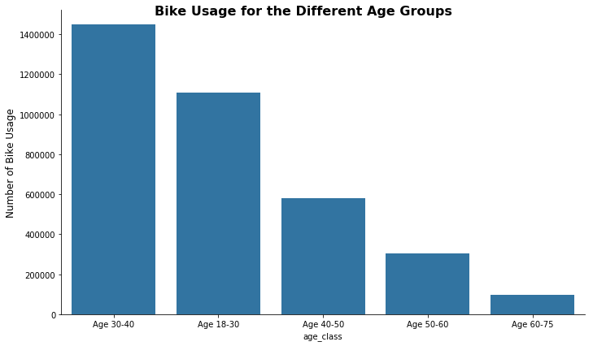

```python
g = sb.catplot(data=dfc , x='age_class', kind='count', color=base_color,
               height=6, aspect=10/6,
               order = dfc['age_class'].value_counts().index);
plt.ylabel('Number of Bike Usage',fontsize=12);
g.fig.suptitle('Bike Usage for the Different Age Groups', fontsize=16, fontweight='semibold');
plt.savefig('image01_2.png');
```

**Comment**: Box-plot shows that most of the bike sharing system users are around ~33 years old. Parallel to this finding, the bar-chart above shows that people who are between 30-40 years old mostly use the bike sharing system. Young people (age 18-30) do not prefer bike sharing system as much as middle age (30-40) people. After 40 years old, the demand to bike sharing system is gradually decreased as expected.

### Bike usage according to daily hour, day and month

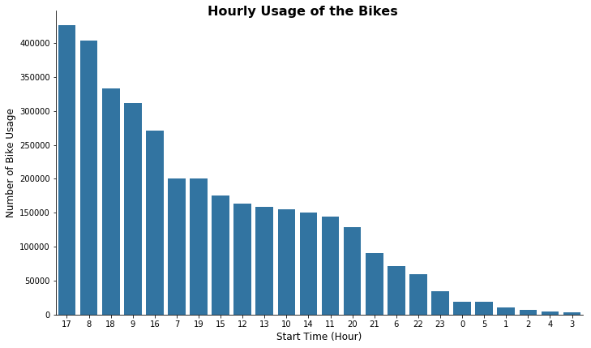

```python
#HOURLY BIKE USAGE
g = sb.catplot(data=dfc , x='start_time_hour', kind='count', color=base_color,
               height=6, aspect=10/6,
               order = dfc['start_time_hour'].value_counts().index)
g.set_axis_labels("Hours", "Number of Bike Trips")
plt.xlabel('Start Time (Hour)',fontsize=12)
plt.ylabel('Number of Bike Usage',fontsize=12)
g.fig.suptitle('Hourly Usage of the Bikes', fontsize=16, fontweight='semibold');
plt.savefig('image02.png');
```

**Comment**: According the hourly usage for all times, it seems that 5 p.m. and 8 a.m. are the top-2 hours for bike usage. Then 6 p.m. and 9 a.m. are the second top-2 hours for the bike usage. These hours are simply check-in and check-out hours for working people.  
The least hours for bike users are the hours between 0-5 a.m. as expected.

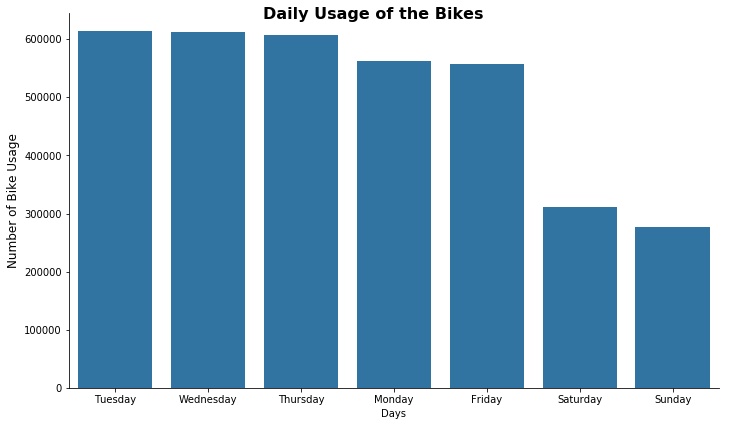

```python
#DAILY BIKE USAGE
g = sb.catplot(data=dfc , x='start_time_weekday', kind='count', color=base_color,
               height=6, aspect=10/6,
               order = dfc['start_time_weekday'].value_counts().index)
g.set_axis_labels("Days", "Number of Bike Trips")
plt.ylabel('Number of Bike Usage',fontsize=12)
g.fig.suptitle('Daily Usage of the Bikes', fontsize=16, fontweight='semibold');
plt.savefig('image03.png');
```

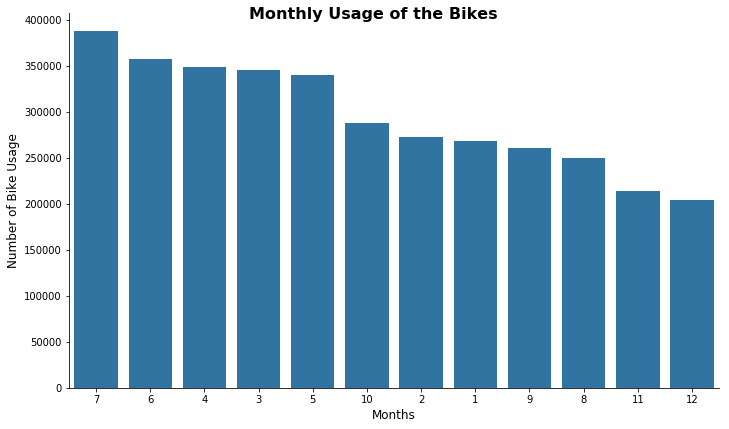

```python
#MONTHLY BIKE USAGE
g = sb.catplot(data=dfc , x='start_time_month', kind='count', color=base_color,
               height=6, aspect=10/6,
               order = dfc['start_time_month'].value_counts().index)
g.set_axis_labels("Hours", "Number of Bike Trips")
plt.xlabel('Months',fontsize=12)
plt.ylabel('Number of Bike Usage',fontsize=12)
g.fig.suptitle('Monthly Usage of the Bikes', fontsize=16, fontweight='semibold');
plt.savefig('image04.png');
```

**Comment**: According the monthly usage, it seems that the highest amount of bike usage occurs in July based on the data. After July; June, April, March and May comes respectively and their levels are quite close to each others.  
The least usages occur in November and December as expected due to climate. Our findings seem logical.

### Trip durations over days

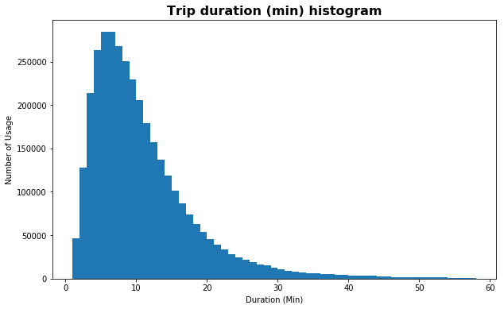

```python
bin_edges = np.arange(1, 58+1, 1)
#
plt.figure(figsize=(10,6))
plt.hist(data = dfc, x = 'duration_min', bins = bin_edges)
plt.title("Trip duration (min) histogram", fontsize=16, fontweight='semibold')
plt.xlabel('Duration (Min)')
plt.ylabel('Number of Usage');
plt.savefig('image05.png');
```

**Comment:** It seems that most people use the bike sharing system not longer than 30 minutes! Additionally, users use the bikes around 5-15 minutes. Consequently, people use the bike sharing system for short trips in general.

### User types

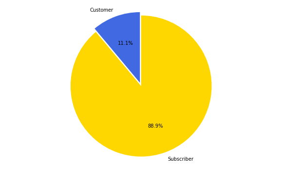

```python
cus_pro = dfc.query('user_type == "Customer"')['bike_id'].count() / dfc['bike_id'].count()
sub_pro = dfc.query('user_type == "Subscriber"')['bike_id'].count() / dfc['bike_id'].count()
proportions = [cus_pro, sub_pro]
#
plt.figure(figsize = [10, 6])
labels = ['Customer', 'Subscriber']
explode = (0, 0.05)
colors = ['royalblue', 'gold'] #Ref: matplotlib.org/3.1.0/gallery/color/named_colors.html
#
plt.pie(proportions, explode=explode, labels=labels, colors = colors,
        autopct='%1.1f%%', startangle=90);
plt.axis('equal');
plt.savefig('image06.png');
```

**Conclusion:** Subscribers use the bike sharing system significantly more than customers! Most probably being subscriber provides some discounts!

### Hourly bike usage according to user type

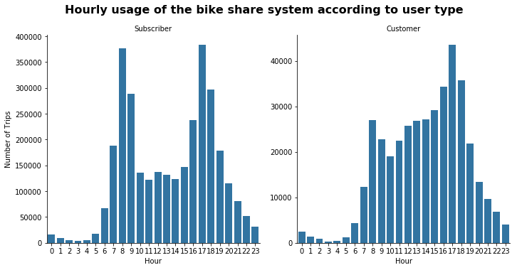

```python
plt.figure(figsize = [10, 6]);
g = sb.catplot(data=dfc, x='start_time_hour', col="user_type", kind='count',
               sharey = False, color = base_color);
g.set_axis_labels("Hour", "Number of Trips");
g.set_titles("{col_name}");
g.fig.suptitle('Hourly usage of the bike share system according to user type',
               y=1.05, fontsize=16, fontweight='semibold');
plt.savefig('image07.png');
```

**Conclusion:** According the plots above, it seems that use cases in terms of daily hour show differences between subcribers and customers. Subscribers are tend to use the bike sharing system in check-in an check-out days for the work places (8-9 a.m and 5-6 p.m.) and demand from subscribers are low between 10 a.m. and 15 p.m.! However, customers are tend to use bike sharing system mostly starting from 10 a.m. up to 5 p.m.! And also customers use the bike sharing system around 8-9 a.m. but not much as subscribers as use.

### Monthly bike usage according to user type

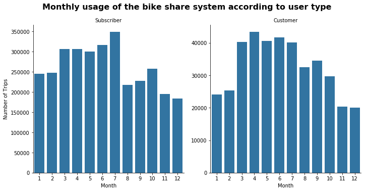

```python
plt.figure(figsize = [10, 6]);
g = sb.catplot(data=dfc, x='start_time_month', col="user_type", kind='count',
               sharey = False, color = base_color);
g.set_axis_labels("Month", "Number of Trips");
g.set_titles("{col_name}");
g.fig.suptitle('Monthly usage of the bike share system according to user type',
               y=1.05, fontsize=16, fontweight='semibold');
plt.savefig('image08.png');
```

**Conclusion:** According the plots above, it seems that use cases in terms of monthly show similarities between subcribers and customers. Both subscribers and customers are tend to use the bike sharing system in spring and sumer seasons as expected. However, top months are different. Subscribers mostly use the bike sharing system in july however customers use in april at most.

### Hourly bike usage according to gender

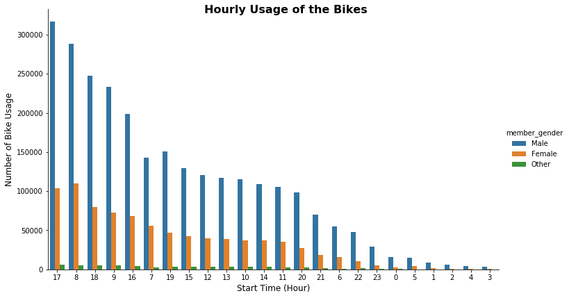

```python
g = sb.catplot(data=dfc , x='start_time_hour', kind='count',
               hue='member_gender', height=6, aspect=10/6,
               order = dfc['start_time_hour'].value_counts().index)
g.set_axis_labels("Hours", "Number of Bike Trips")
plt.xlabel('Start Time (Hour)',fontsize=12)
plt.ylabel('Number of Bike Usage',fontsize=12)
g.fig.suptitle('Hourly Usage of the Bikes', fontsize=16, fontweight='semibold');
plt.savefig('image09.png');
```

**Comment**: Males, Females and Others (here it's assumed that they have different sexual identities), show not identical but similar preferences in terms of bike usage hours. The second finding from the above plot is that males are significantly higher than females in terms of bike usage.  
Aditionally, here log-scale could be used. However, there will be an explanatry part of this study and log-scale can be confusing for people who are not familiar with logarithms.

### Monthly bike usage according to gender

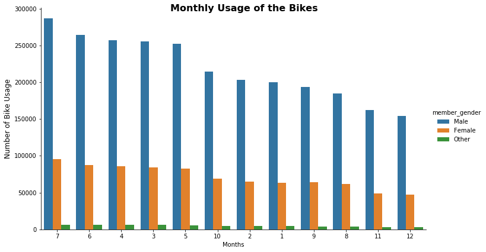

```python
g = sb.catplot(data=dfc , x='start_time_month', kind='count',
               hue='member_gender', height=6, aspect=10/6,
               order = dfc['start_time_month'].value_counts().index)
g.set_axis_labels("Months", "Number of Bike Trips")
#plt.xlabel('Start Time (Month)',fontsize=12)
plt.ylabel('Number of Bike Usage',fontsize=12)
g.fig.suptitle('Monthly Usage of the Bikes', fontsize=16, fontweight='semibold');
plt.savefig('image10.png');
```

**Comment**: Males, Females and Others (here it's assumed that they have different sexual identities), show not identical but similar preferences in terms of bike usage months. For both males and females the top-3 months are july, june and april respectively.

#### CONCLUSION

Speaking of ecomic use, about 89% of people who use the system prefer to become a member because membership provides cheaper usage.

[figure not shown]

#### CONCLUSION

When we look at the usage on day basis, it is seen that the system is used more during the week. Again, this shows that the system is used more by the working people.

[figure not shown]

#### CONCLUSION

In addition, if you take a look at the commonly used routes:

San Francisco Ferry Building - The Embarcadero at Sansome St  
The Embarcadero at Sansome St in Steuart St at Market St  
Berry St at 4th St - San Francisco Ferry Building (Harry Bridges Plaza)  
Grand Ave at Perkins St. - 19th Street BART Station  
19th Street BART Station - Grand Ave at Perkins St  
San Francisco Ferry Building - Berry St at 4th St  
The Embarcadero at Sansome St - San Francisco Ferry Building (Harry Bridges Plaza)  
Steuart St at Market St - The Embarcadero at Sansome St  
Townsend St at 7th St - San Francisco Caltrain Station 2  
Market St at 10th St - San Francisco Caltrain Station 2 (Townsend St at 4th St)

We can see that the system is mostly used in areas **where white collars work**.

#### CONCLUSION

Consequently, to deploy a similar system in another country, the stations need to be located close to the offices, especially those with white-collar workers. Advertisements should be channeled to middle-aged people as well as to men by weight.

Reported by Ugur URESIN, MSc.